# Boston Crime Data Analysis

```r
#Read boston crime data
library(tidyverse)
crime_data_boston <- read_csv("crime.csv")

#Check if data is loaded properly
head(crime_data_boston)
```

| INCIDENT_NUMBER | OFFENSE_CODE | OFFENSE_CODE_GROUP | OFFENSE_DESCRIPTION | DISTRICT | REPORTING_AREA | SHOOTING | OCCURRED_ON_DATE | YEAR | MONTH | DAY_OF_WEEK | HOUR | UCR_PART | STREET | Lat | Long | Location |
| --- | --- | --- | --- | --- | --- | --- | --- | --- | --- | --- | --- | --- | --- | --- | --- | --- |
| I182080058 | 02403 | Disorderly Conduct | DISTURBING THE PEACE | E18 | 495 | NA | 2018-10-03 20:13:00 | 2018 | 10 | Wednesday | 20 | Part Two | ARLINGTON ST | 42.26261 | -71.12119 | (42.26260773, -71.12118637) |
| I182080053 | 03201 | Property Lost | PROPERTY - LOST | D14 | 795 | NA | 2018-08-30 20:00:00 | 2018 | 8 | Thursday | 20 | Part Three | ALLSTON ST | 42.35211 | -71.13531 | (42.35211146, -71.13531147) |
| I182080052 | 02647 | Other | THREATS TO DO BODILY HARM | B2 | 329 | NA | 2018-10-03 19:20:00 | 2018 | 10 | Wednesday | 19 | Part Two | DEVON ST | 42.30813 | -71.07693 | (42.30812619, -71.07692974) |
| I182080051 | 00413 | Aggravated Assault | ASSAULT - AGGRAVATED - BATTERY | A1 | 92 | NA | 2018-10-03 20:00:00 | 2018 | 10 | Wednesday | 20 | Part One | CAMBRIDGE ST | 42.35945 | -71.05965 | (42.35945371, -71.05964817) |
| I182080050 | 03122 | Aircraft | AIRCRAFT INCIDENTS | A7 | 36 | NA | 2018-10-03 20:49:00 | 2018 | 10 | Wednesday | 20 | Part Three | PRESCOTT ST | 42.37526 | -71.02466 | (42.37525782, -71.02466343) |
| I182080049 | 01402 | Vandalism | VANDALISM | C11 | 351 | NA | 2018-10-02 20:40:00 | 2018 | 10 | Tuesday | 20 | Part Two | DORCHESTER AVE | 42.29920 | -71.06047 | (42.29919694, -71.06046974) |

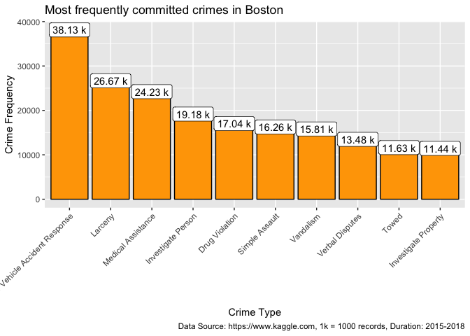

```r
#let's do exploratory data analysis
library(tidyverse)

#Plot information about what crimes are most frequently occuring in Boston.This will help law inforcement as well as community supoort group to divert or allocate type of resources.
crime_data_boston %>%
  select(OFFENSE_CODE_GROUP, DAY_OF_WEEK) %>%
  group_by(OFFENSE_CODE_GROUP) %>%
  filter(OFFENSE_CODE_GROUP != "Other") %>%
  summarise(crime_frequency = n()) %>%
  arrange(desc(crime_frequency)) %>%
  head(10) %>%
  ggplot(aes(x = reorder(OFFENSE_CODE_GROUP, desc(crime_frequency)), y = crime_frequency)) +
  geom_col(fill = "orange", color = "black") +
  ggtitle("Most frequently committed crimes in Boston") +
  labs(x = "Crime Type", y = "Crime Frequency", caption = "Data Source: https://www.kaggle.com, 1k = 1000 records, Duration: 2015-2018") +
  geom_label(aes(x = OFFENSE_CODE_GROUP, y = crime_frequency, label = paste(round(crime_frequency/1000, digits = 2), "k")))+
  theme(axis.text.x = element_text(angle = 45, hjust = 1))
```

1. “Vehicle Accidents” are the highest crimes committed followed by “Larceny”.
2. This provides very useful insights to law enforcement in order to understand the crime situation in Boston as well as it will be helpful for law enforcement to develop skilled resources to efficiently handle crimes which are most occurring.
3. “Drug Violation” is one of the top 5 committed crimes in Boston. It’s one of the concerning facts that was found out through the analysis.
4. Diving deep in the further analysis will also be helpful for local community support group or pharmacy and hospitals to allocate resources in the areas where “Drug Violation” happens most.

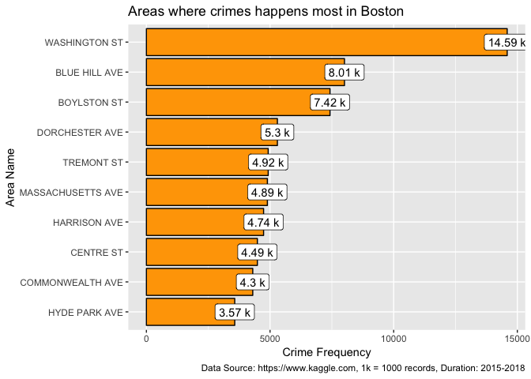

```r
#Let's find out the areas where most crimes are committed in Boston.
crime_data_boston %>%
  select(STREET) %>%
  group_by(STREET) %>%
  filter(STREET != "NA") %>%
  summarise(crime_frequency = n()) %>%
  arrange(desc(crime_frequency)) %>%
  head(10) %>%
  ggplot(aes(x = reorder(STREET, crime_frequency), y = crime_frequency)) +
  geom_bar(stat = "identity",fill = "orange", color = "black", position = "dodge") +
  coord_flip() +
  geom_label(aes(x = STREET, y = crime_frequency, label = paste(round(crime_frequency/1000, digits = 2), "k"))) +
  ggtitle("Areas where crimes happens most in Boston") +
  labs(x = "Area Name", y = "Crime Frequency", caption = "Data Source: https://www.kaggle.com, 1k = 1000 records, Duration: 2015-2018")
```

1. Areas with highest crimes are 1. Washington Street, 2. Blue Hill Avenue, 3. Boylston Street, 4. Dorchester Avenue, 5.Tremont Street.

[figure not shown]

```r
#Extract instances of drug charges
drug_crimes <- crime_data_boston %>% select(OFFENSE_CODE_GROUP, Lat, Long) %>%
  filter(OFFENSE_CODE_GROUP == "Drug Violation")

#Plot on a map
require(ggmap)
register_google(key = "AIzaSyA5XYT88pSr8VdMuktU7MC4vLUFalfpLEk")

#Find map center (lattitude and longitude) for "Boston, MA"
map.center <- geocode("Boston, MA")

#Create map object to plot datapoints
Boston_map <- qmap(c(lon=map.center$lon, lat=map.center$lat), zoom=12)


Boston_map + geom_point(aes(x=Long, y=Lat), data=drug_crimes, size=2, alpha=0.2, color="red") +
  ggtitle("Drug Charges in Boston by Location (2015-2018)")
```

1. This geo-map gives information about areas with high desnsity of drug crimes. Having aceess to hospitals or pharmacy will be helpful to lower down crimes in these areas.